# Part II - (Data Visualization of FordGoBike February 2019 Data)

## by (Agunoweh Timiebi)

## Investigation Overview

> The goal of this project is to illustrate the value and significance of data visualization techniques in the data analysis procedure. First, we perform the exploration and visualization in Python using well-known libraries like NumPy, pandas, Matplotlib, and Seaborn. The second part will then consist of a brief presentation that highlights an intriguing finding from our data.

## Dataset Overview

> This data collection contains details on each trip taken in a bike-sharing programme that serves the greater San Francisco Bay region. https://www.lyft.com/bikes/bay-wheels/system-data. For this initiative, February will be our only focus.

The following information is included in the anonymised data for each trip:

- Trip Duration (seconds)
- Start Time and Date
- End Time and Date
- Start Station ID
- Start Station Name
- End Station ID
- End Station Name
- End Station Latitude
- End Station Longitude
- Bike ID
- User Type (Subscriber or Customer – “Subscriber” = Member or “Customer” = Casual)

### 1. Timely Usage Service

- On weekdays rather than weekends, this service is used more frequently.

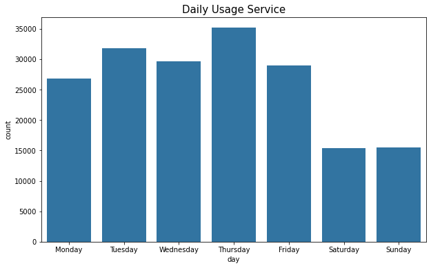

### 2. Service Usage by Weekday

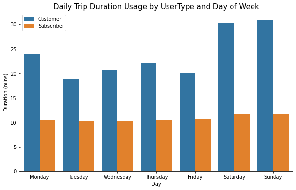

### 3. What is the average length of a trip?

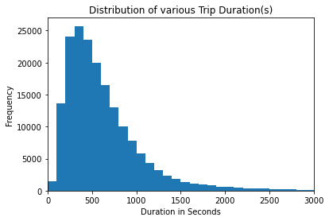

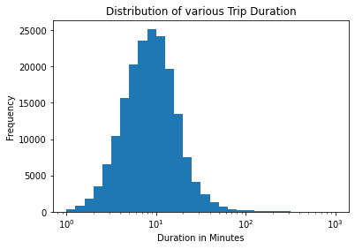